# Project Coursera

Teun Koldeweij

20-1-2020

# Data inspection

A quick inspection of the data Dimensions with the dim() function

### training data

rows x columns

19622, 160

### testing data

rows x columns

20, 160

# Clean data

We delete every column that has NA values. This is a bit rigourus but allows us to come to a condensed dataset more quickly.

```r
training <- training[ , colSums(is.na(training)) == 0]
testing <- testing[, colSums(is.na(testing)) == 0]
```

Now we may want to check current predictors, and filter out those that do not seem to be nessecary for prediction. A simple look at the colNames reveals plenty

```r
colnames(training)
```

```
##  [1] "X"                    "user_name"            "raw_timestamp_part_1"
##  [4] "raw_timestamp_part_2" "cvtd_timestamp"       "new_window"
##  [7] "num_window"           "roll_belt"            "pitch_belt"
## [10] "yaw_belt"             "total_accel_belt"     "gyros_belt_x"
## [13] "gyros_belt_y"         "gyros_belt_z"         "accel_belt_x"
## [16] "accel_belt_y"         "accel_belt_z"         "magnet_belt_x"
## [19] "magnet_belt_y"        "magnet_belt_z"        "roll_arm"
## [22] "pitch_arm"            "yaw_arm"              "total_accel_arm"
## [25] "gyros_arm_x"          "gyros_arm_y"          "gyros_arm_z"
## [28] "accel_arm_x"          "accel_arm_y"          "accel_arm_z"
## [31] "magnet_arm_x"         "magnet_arm_y"         "magnet_arm_z"
## [34] "roll_dumbbell"        "pitch_dumbbell"       "yaw_dumbbell"
## [37] "total_accel_dumbbell" "gyros_dumbbell_x"     "gyros_dumbbell_y"
## [40] "gyros_dumbbell_z"     "accel_dumbbell_x"     "accel_dumbbell_y"
## [43] "accel_dumbbell_z"     "magnet_dumbbell_x"    "magnet_dumbbell_y"
## [46] "magnet_dumbbell_z"    "roll_forearm"         "pitch_forearm"
## [49] "yaw_forearm"          "total_accel_forearm"  "gyros_forearm_x"
## [52] "gyros_forearm_y"      "gyros_forearm_z"      "accel_forearm_x"
## [55] "accel_forearm_y"      "accel_forearm_z"      "magnet_forearm_x"
## [58] "magnet_forearm_y"     "magnet_forearm_z"     "classe"
```

The first seven predictors are concerned with variables other than our desired variables for measurement The choice is made to filter out these. We could also have excluded these in our training model. This would however, make our coding unneccesarily complex and long.

```r
training_data <- training[ , -c(1:7)]
testing_data <- testing[ , -c(1:7)]
```

# Data Splitting

To get the out of sample errors, we split our current trainingset in two. One part is reserved for the training set (70%), and one part will be reserved for the validation set (30%).

```r
set.seed(7826)
partition <- createDataPartition(training_data$classe, p=0.7, times = 1, list = F)
train <- training_data[partition, ]
validation <- training_data[-partition, ]
```

# Predictive algoritms

As a first algorithm we fit a classfication tree. Because of the interpretability, it is a great first model to apply and get a sense of the data. Instead of using 10 folds, we use 5 folds on the data. This is more convenient when running this model regularly in terms of computing time.

```r
control <- trainControl(method = "cv", number =5)
train_rpart <- train(classe ~ ., data = train, method = "rpart", trControl = control)
print(train_rpart, digits = 2)
```

```
## CART
##
## 13737 samples
##    52 predictor
##     5 classes: 'A', 'B', 'C', 'D', 'E'
##
## No pre-processing
## Resampling: Cross-Validated (5 fold)
## Summary of sample sizes: 10990, 10990, 10990, 10989, 10989
## Resampling results across tuning parameters:
##
##   cp     Accuracy  Kappa
##   0.031  0.53      0.380
##   0.060  0.39      0.170
##   0.116  0.32      0.049
##
## Accuracy was used to select the optimal model using the largest value.
## The final value used for the model was cp = 0.031.
```

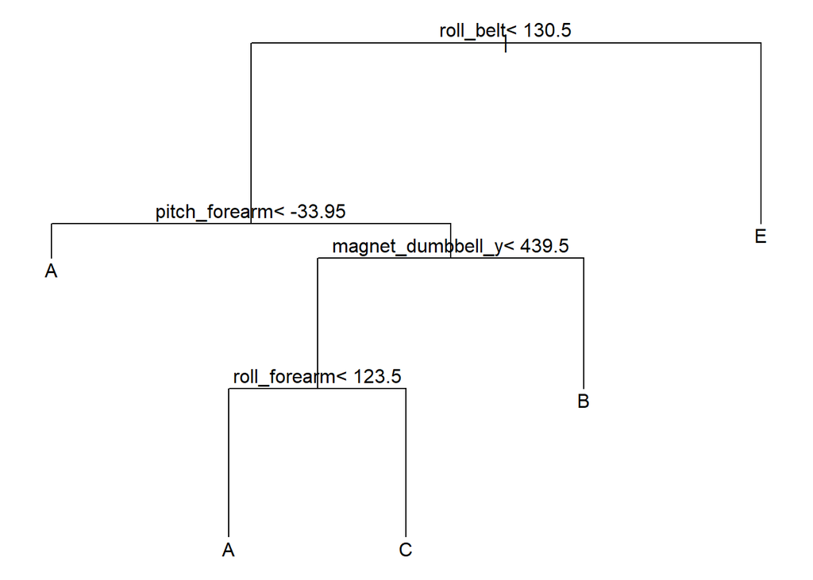

```r
par(mar = c(1, 1, 1, 1))
plot(train_rpart$finalModel)
text(train_rpart$finalModel)
```

The plotted model reveals the initial decision rules made by the algorithm. No time was spent on making this plot more appealing. Now, we can use this trained model on our validation set.

```r
predict_rpart <- predict(train_rpart, validation)
(confusion_rpart <- confusionMatrix(validation$classe, predict_rpart))
```

```
## Confusion Matrix and Statistics
##
##           Reference
## Prediction    A    B    C    D    E
##          A 1510   27  134    0    3
##          B  464  410  265    0    0
##          C  467   37  522    0    0
##          D  432  163  369    0    0
##          E  164  144  293    0  481
##
## Overall Statistics
##
##                Accuracy : 0.4967
##                  95% CI : (0.4838, 0.5095)
##     No Information Rate : 0.5161
##     P-Value [Acc > NIR] : 0.9986
##
##                   Kappa : 0.3425
##
##  Mcnemar's Test P-Value : NA
##
## Statistics by Class:
##
##                      Class: A Class: B Class: C Class: D Class: E
## Sensitivity            0.4972  0.52497   0.3298       NA  0.99380
## Specificity            0.9424  0.85717   0.8828   0.8362  0.88872
## Pos Pred Value         0.9020  0.35996   0.5088       NA  0.44455
## Neg Pred Value         0.6374  0.92183   0.7816       NA  0.99938
## Prevalence             0.5161  0.13271   0.2690   0.0000  0.08224
## Detection Rate         0.2566  0.06967   0.0887   0.0000  0.08173
## Detection Prevalence   0.2845  0.19354   0.1743   0.1638  0.18386
## Balanced Accuracy      0.7198  0.69107   0.6063       NA  0.94126
```

```r
(accuracy_rpart <- confusion_rpart$overall[1])
```

```
##  Accuracy
## 0.4966865
```

0.4966865 is our accurary and also represents our out of sample error as 1 - 0.4966865 This is not a very good predictive model and thus we should look for other options.

# Advanced Classification Tree - Random Forest

Because a single classification tree was not able to product a very good model. We apply a advanced classification tree technique, the random forest. We use the same control mechanics as with the single tree. 5 folds is really helping in a faster calculation here.

```r
train_rf <- train(classe ~ ., data = train, method = "rf", trControl = control)
print(train_rf, digits = 2)
```

```
## Random Forest
##
## 13737 samples
##    52 predictor
##     5 classes: 'A', 'B', 'C', 'D', 'E'
##
## No pre-processing
## Resampling: Cross-Validated (5 fold)
## Summary of sample sizes: 10991, 10990, 10990, 10988, 10989
## Resampling results across tuning parameters:
##
##   mtry  Accuracy  Kappa
##    2    0.99      0.99
##   27    0.99      0.99
##   52    0.98      0.98
##
## Accuracy was used to select the optimal model using the largest value.
## The final value used for the model was mtry = 27.
```

```r
predict_rf <- predict(train_rf, validation)
(conf_rf <- confusionMatrix(validation$classe, predict_rf))
```

```
## Confusion Matrix and Statistics
##
##           Reference
## Prediction    A    B    C    D    E
##          A 1671    2    0    0    1
##          B    4 1134    1    0    0
##          C    0    8 1013    5    0
##          D    0    0   16  947    1
##          E    0    1    1    9 1071
##
## Overall Statistics
##
##                Accuracy : 0.9917
##                  95% CI : (0.989, 0.9938)
##     No Information Rate : 0.2846
##     P-Value [Acc > NIR] : < 2.2e-16
##
##                   Kappa : 0.9895
##
##  Mcnemar's Test P-Value : NA
##
## Statistics by Class:
##
##                      Class: A Class: B Class: C Class: D Class: E
## Sensitivity            0.9976   0.9904   0.9825   0.9854   0.9981
## Specificity            0.9993   0.9989   0.9973   0.9965   0.9977
## Pos Pred Value         0.9982   0.9956   0.9873   0.9824   0.9898
## Neg Pred Value         0.9991   0.9977   0.9963   0.9972   0.9996
## Prevalence             0.2846   0.1946   0.1752   0.1633   0.1823
## Detection Rate         0.2839   0.1927   0.1721   0.1609   0.1820
## Detection Prevalence   0.2845   0.1935   0.1743   0.1638   0.1839
## Balanced Accuracy      0.9984   0.9947   0.9899   0.9910   0.9979
```

```r
(accuracy_rf <- conf_rf$overall[1])
```

```
##  Accuracy
## 0.9916737
```

0.9916737 is our accurary and also represents our out of sample error as 1 - 0.9916737 This is a much better predictive model in comparison with our single tree. We can be confident that this model with perform well on our test set aswell.

# Final prediction on our Test Set.

```r
(predict_test <- predict(train_rf, testing))
```

```
##  [1] B A B A A E D B A A B C B A E E A B B B
## Levels: A B C D E
```

```r
test_A <- predict_test == "A"
amount_A <- mean(test_A)
```

Above you see the predicted classes from our test set by our random forest model

# Conclusion and remarks

The prediction model shows the predicted classe: A to E. It seems only 0.35 of the subjects is correctly performing the excersizes.

We have now created a algorithm to predict the class in which a subject wil fall, thus finalizing this excersize.